# Day 15: Beacon Exclusion Zone

@Andi@tech.lgbt

```r
library(tidyverse)
```

```r
read_sensor_dat <- function(filename) {
  tibble(str = read_lines(filename)) |>
    extract(
      str,
      into = c("Sx", "Sy", "Bx", "By"),
      regex = "Sensor at x=(-?[0-9]+), y=(-?[0-9]+): closest beacon is at x=(-?[0-9]+), y=(-?[0-9]+)"
    ) |>
    mutate_all(as.numeric) |>
    mutate(
      d = manhat(Sx, Bx, Sy, By)
    )
}
```

```r
manhat <- function(x1,x2,y1,y2) {
  abs(x1 - x2) + abs(y1 - y2)
}
```

```r
testdat <- read_sensor_dat("aoc15test.txt")
testdat
```

| Sx | Sy | Bx | By | d |
| --- | --- | --- | --- | --- |
| 2 | 18 | -2 | 15 | 7 |
| 9 | 16 | 10 | 16 | 1 |
| 13 | 2 | 15 | 3 | 3 |
| 12 | 14 | 10 | 16 | 4 |
| 10 | 20 | 10 | 16 | 4 |
| 14 | 17 | 10 | 16 | 5 |
| 8 | 7 | 2 | 10 | 9 |
| 2 | 0 | 2 | 10 | 10 |
| 0 | 11 | 2 | 10 | 3 |
| 20 | 14 | 25 | 17 | 8 |

[output cut: 4 more lines]

```r
scan_row <- function(sensors, here_y, from_x, to_x) {
  gaps   <- 0

  for (here_x in from_x:to_x) {
    sensors_here <- sensors |>
      mutate(
        d_here = manhat(here_x, Sx, here_y, Sy),
        closer = d_here <= d,
        beacon_here = here_x == Bx & here_y == By
      )

    if (any(sensors_here$closer) && !any(sensors_here$beacon_here))
    {
      gaps <- gaps + 1
    }
  }

  gaps
}
```

```r
solve_it <- function(dat, y) {
  scan_row(
    dat,
    here_y = y,
    from_x = min(dat$Sx - dat$d),
    to_x   = max(dat$Sx + dat$d)
  )
}
```

The right answer is 26:

```r
solve_it(read_sensor_dat("aoc15test.txt"), y = 10)
```

```
[1] 26
```

Worked!

## Part 1:

It’s a much bigger search space but I reckon it’ll work… Shall send this off to do its thing in the background:

```r
solve_it(read_sensor_dat("aoc15.txt"), y = 2000000)
```

5144286

Yes! Eventually (~4 hours).

## Part 2:

Try brute forcing again for the small one.

```r
scan_rect <- function(sensors, from_x, to_x, from_y, to_y) {
  res <- NA

  for (here_y in from_y:to_y)
    for (here_x in from_x:to_x) {
      sensors_here <- sensors |>
        mutate(
          d_here = manhat(here_x, Sx, here_y, Sy),
          closer = d_here <= d,
          beacon_here = here_x == Bx & here_y == By
        )

      if (!any(sensors_here$closer) &&
          !any(sensors_here$beacon_here))
      {
        res <- c(here_x, here_y)
        break
      }
    }

  res
}
```

```r
foundit <- scan_rect(testdat, 0, 20, 0, 20)
foundit
```

```
[1] 14 11
```

```r
foundit[1] * 4000000 + foundit[2]
```

```
[1] 56000011
```

This is correct, so at least I’m confident I get the problem spec.

The full problem has an absurdly large search space so this really isn’t going to work…

```r
4000000^2
```

```
[1] 1.6e+13
```

Let’s not.

## Some pictures

```r
realdat <- read_sensor_dat("aoc15.txt")
```

```r
drawpolys <-
  function(dat,
           xlim,
           ylim,
           col = "grey",
           border = "black",
           outside = "black",
           xsearchlim,
           ysearchlim) {
    plot(
      1,
      xlim = xlim,
      ylim = ylim,
      xlab = "x",
      ylab = "y",
      type = "n"
    )
    polygon(
      x = c(xsearchlim[1], xsearchlim[2], xsearchlim[2], xsearchlim[1]),
      y = c(ysearchlim[1], ysearchlim[1], ysearchlim[2], ysearchlim[2]),
      border = outside,
      col = "yellow"
    )

    for (r in 1:nrow(dat)) {
      x_c   <- dat[r,]$Sx
      y_c   <- dat[r,]$Sy
      d_h   <- dat[r,]$d + .5

      polygon(
        x = c(x_c, x_c - d_h, x_c, x_c + d_h),
        y = c(y_c + d_h, y_c, y_c - d_h, y_c),
        col = col,
        border = border
      )
    }
    polygon(
      x = c(xsearchlim[1], xsearchlim[2], xsearchlim[2], xsearchlim[1]),
      y = c(ysearchlim[1], ysearchlim[1], ysearchlim[2], ysearchlim[2]),
      border = outside
    )

  }
```

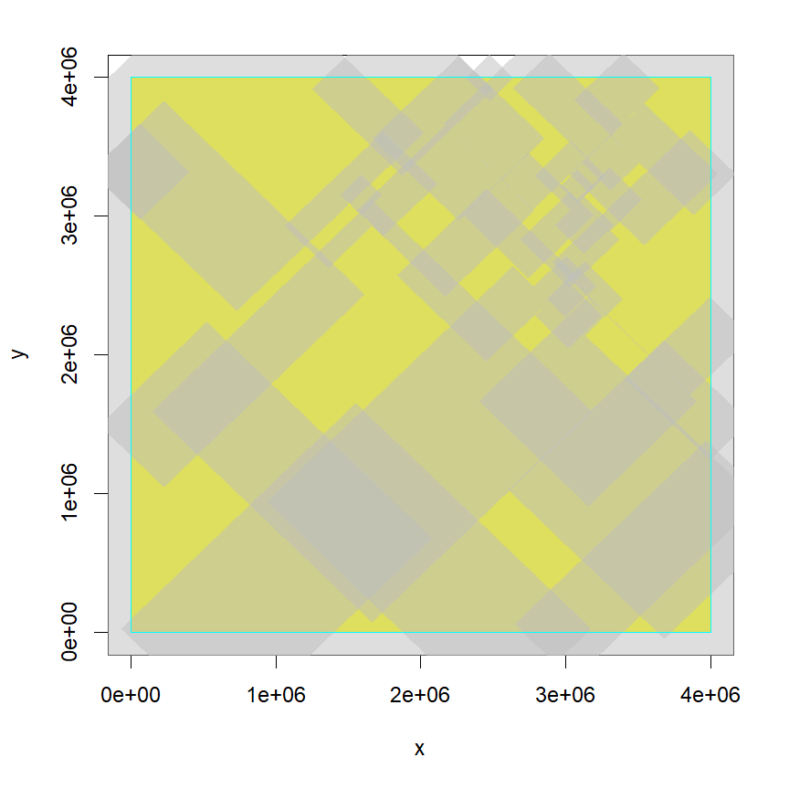

```r
drawpolys(
  realdat,
  c(0, 4000000),
  c(0, 4000000),
  col = adjustcolor("grey",alpha.f=.5),
  border = NA,
  outside = "cyan",
  xsearchlim = c(0,4e6),
  ysearchlim = c(0,4e6)
)
```

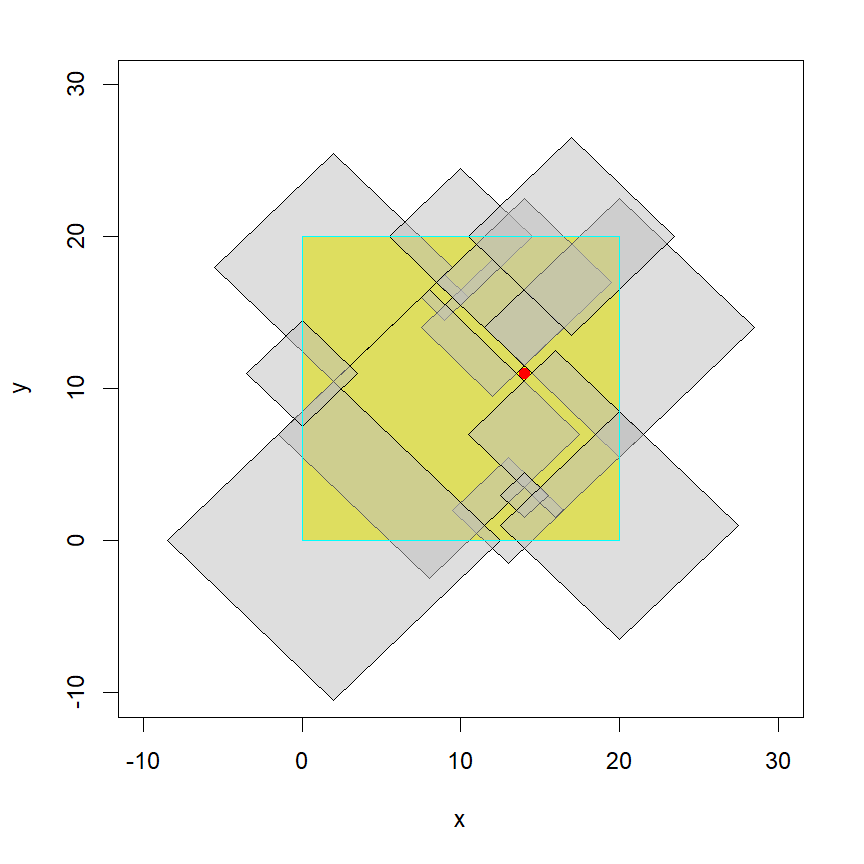

```r
drawpolys(
  testdat,
  c(-10, 30),
  c(-10, 30),
  col = adjustcolor("grey", alpha.f = .5),
  border = "black",
  outside = "cyan",
  xsearchlim = c(0, 20),
  ysearchlim = c(0, 20)
)
points(14, 11, pch = 19, col = "red")
```

Okay that’s lovely – I can spot the correct answer for the small problem. No chance for the larger one. I really need a way to find the gap automagically.

I went on a highly entertaining though ultimately fruitless journey into integer programming using the Big-M method to try to represent the problem. Looks like {sf} might be able to help. I can reuse `drawpolys`.

```r
library(sf)
```

```r
search_region <- function(xsearchlim, ysearchlim) {
  coords <-
    cbind(
      x = c(xsearchlim[1], xsearchlim[2], xsearchlim[2], xsearchlim[1],
            xsearchlim[1]),
      y = c(ysearchlim[1], ysearchlim[1], ysearchlim[2], ysearchlim[2],
            ysearchlim[1])
    )
  list(coords) |> st_polygon()
}
```

The following function has an entertaining history. I started by trying to union all the shapes together and then fiddling around with intersections and set differences to find the hole. Then I realised I could just begin with a polygon representing the search space and iteratively remove each shape representing the Manhattan area from it. The d + 0.5 bit is magic to approximate an integer space using a continuous one.

```r
find_hole <- function(dat, xsearchlim, ysearchlim) {
  res <- search_region(xsearchlim, ysearchlim)

  for (r in 1:nrow(dat)) {
    x_c   <- dat[r,]$Sx
    y_c   <- dat[r,]$Sy
    d_h   <- dat[r,]$d+.5

    this_poly <- cbind(
      x = c(x_c, x_c - d_h, x_c, x_c + d_h, x_c),
      y = c(y_c + d_h, y_c, y_c - d_h, y_c, y_c + d_h)
    ) |> list() |> st_polygon()

    res <- st_difference(res, this_poly)
  }

  res
}
```

Okay… this is much better! The correct answer is 14, 11.

```r
find_hole(testdat, c(0,20), c(0,20))
```

```
POLYGON ((14.5 11, 14 10.5, 13.5 11, 14 11.5, 14.5 11))
```

Let’s try with the actual data:

```r
find_hole(realdat, c(0, 4000000), c(0, 4000000))
```

```
POLYGON ((2557297 3267339, 2557297 3267340, 2557298 3267339, 2557297 3267339, 2557297 3267339))
```

That’s a significantly smaller search space than I started with :) Fingers crossed.

```r
good_grief <- scan_rect(realdat, 2557297, 2557298, 3267339, 3267340)
good_grief
```

```
[1] 2557297 3267339
```

Whoop whoop!

```r
options(scipen=999)
good_grief[1] * 4000000 + good_grief[2]
```

```
[1] 10229191267339
```

We’re done.